# Computer Lab 01 — `rjags`

Berwin A Turlach

March 06, 2021

# Introduction

If you are on a system on which you cannot run `OpenBUGS` but the R package `rjags` and `JAGS` is available (e.g. a MAC OSX system or a Linux operating system), then the following shows how to run the two computer lab examples using the `rjags` package.

# Exercise 1

Assume we have the `BUGS` code for that example in a file called `Ex1.bug`:

```
model {
  Y ~ dbin(0.5, 8)
  P2 <- step(2.5 -Y ) # does Y = 2, 1, or 0?
}
```

First, we load the package `rjags`:

```r
library(rjags)
```

With JAGS, the model checking and compiling step is done in one step. Hence, we compile our model, and specify that we want to run one chain, by the following command:

```r
mod <- jags.model("Ex1.bug", n.chains=1)
```

If we want to run the chain for 10,000 iterations while monitoring `Y` and `P2`, we have to issue the following command:

```r
out <- coda.samples(mod, c("Y", "P2"), n.iter=10000)
```

[output not shown]

The statistics on each monitored node we can obtain as follows:

```r
summary(out)
```

```
Iterations = 1:10000
Thinning interval = 1
Number of chains = 1
Sample size per chain = 10000

1. Empirical mean and standard deviation for each variable,
   plus standard error of the mean:

     Mean    SD Naive SE Time-series SE
P2 0.1489 0.356  0.00356        0.00356
Y  3.9912 1.423  0.01423        0.01423

2. Quantiles for each variable:

   2.5% 25% 50% 75% 97.5%
P2    0   0   0   0     1
Y     1   3   4   5     7
```

While the empirical densities of the simulated values are produced by the following command:

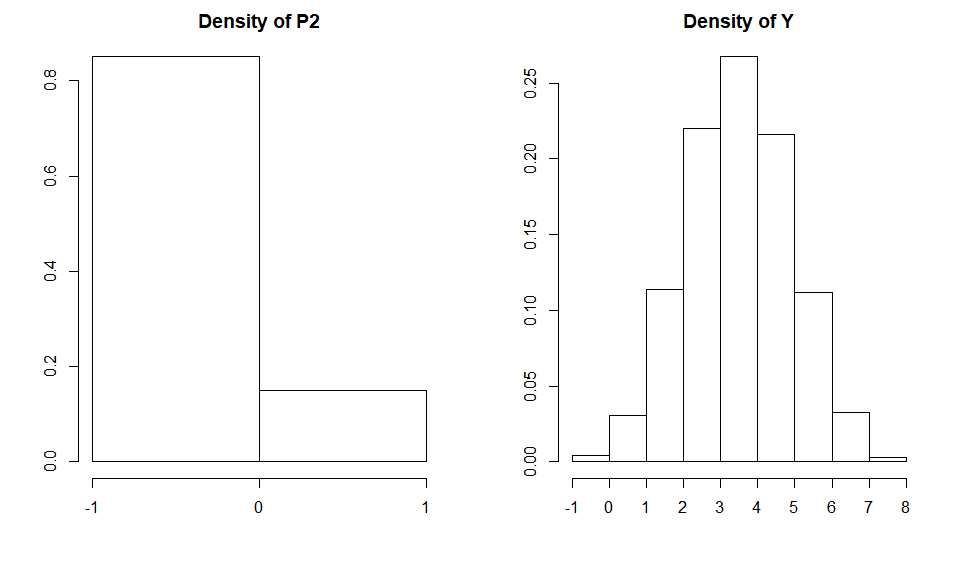

```r
plot(out, trace=FALSE)
```

# Exercise 2

To run this example in `JAGS` we have to make some slight changes to the code as `JAGS` does not have a function called `ranked` directly implemented. Hence, we sort the object `cum.step` and then take the last value of the sorted vector. Thus, for running in `JAGS` the `BUGS` code is as follows and, say, we have the code in a file called `Ex2-jags.bug`:

```
model {
  for(i in 1:20) {
     Y[i] ~ dgamma(4, 0.04)
  }
  cum[1] <- Y[1]
  for(i in 2:20) {
    cum[i] <- cum[i-1] + Y[i]
  }
  for(i in 1:20) {
    cum.step[i] <- i*step(1000 - cum[i])
  }
  cum.step.sorted <- sort(cum.step)
  number <- cum.step.sorted[20]     # maximum number in cum.step
  check  <- equals(cum.step[20], 0) # always 1 if I=20 big enough
}
```

First, we load the package `rjags`:

```r
library(rjags)
```

With JAGS, the model checking and compiling step is done in one step. Hence, we compile our model, and specify that we want to run one chain, by the following command:

```r
mod <- jags.model("Ex2-jags.bug", n.chains = 1)
```

```r
out <- coda.samples(mod, c("number", "Y[1]", "check"), n.iter=10000)
```

[output not shown]

The statistics on each monitored node we can obtain as follows:

```r
summary(out)
```

```
Iterations = 1:10000
Thinning interval = 1
Number of chains = 1
Sample size per chain = 10000

1. Empirical mean and standard deviation for each variable,
   plus standard error of the mean:

          Mean     SD Naive SE Time-series SE
Y[1]   100.240 50.134  0.50134        0.50134
check    1.000  0.000  0.00000        0.00000
number   9.602  1.585  0.01585        0.01585

2. Quantiles for each variable:

        2.5%   25% 50%   75% 97.5%
Y[1]   26.94 63.64  92 128.1 219.6
check   1.00  1.00   1   1.0   1.0
number  7.00  9.00  10  11.0  13.0
```

While the empirical densities of the simulated values are produced by the following command:

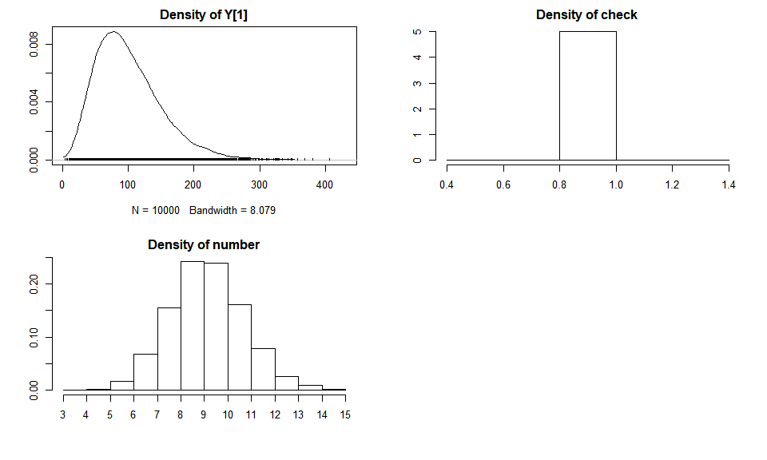

```r
plot(out, trace=FALSE)
```